# chapter 5

Alena Konina

12/1/2019

# Chapter 5. Dimensionality reduction techniques

## Data exploration

```r
human <- read.csv("./data/human.csv", row.names = 1)
str(human)
```

```
## 'data.frame':    155 obs. of  8 variables:
##  $ sed_ratio  : num  0.993 1.003 1.017 1.012 1.032 ...
##  $ labor_ratio: num  0.891 0.819 0.825 0.884 0.829 ...
##  $ ed_exp     : num  17.5 20.2 15.8 18.7 17.9 16.5 18.6 16.5 15.9 19.2 ...
##  $ lifeexp    : num  81.6 82.4 83 80.2 81.6 80.9 80.9 79.1 82 81.8 ...
##  $ gni        : int  64992 42261 56431 44025 45435 43919 39568 52947 42155 32689 ...
##  $ matmort    : int  4 6 6 5 6 7 9 28 11 8 ...
##  $ teenbirths : num  7.8 12.1 1.9 5.1 6.2 3.8 8.2 31 14.5 25.3 ...
##  $ parl       : num  39.6 30.5 28.5 38 36.9 36.9 19.9 19.4 28.2 31.4 ...
```

```r
summary(human)
```

```
##    sed_ratio       labor_ratio         ed_exp         lifeexp
##  Min.   :0.6681   Min.   :0.1857   Min.   : 5.40   Min.   :49.00
##  1st Qu.:1.0032   1st Qu.:0.5984   1st Qu.:11.25   1st Qu.:66.30
##  Median :1.0667   Median :0.7535   Median :13.50   Median :74.20
##  Mean   :1.3523   Mean   :0.7074   Mean   :13.18   Mean   :71.65
##  3rd Qu.:1.3766   3rd Qu.:0.8535   3rd Qu.:15.20   3rd Qu.:77.25
##  Max.   :5.8235   Max.   :1.0380   Max.   :20.20   Max.   :83.50
##       gni            matmort         teenbirths          parl
##  Min.   :   581   Min.   :   1.0   Min.   :  0.60   Min.   : 0.00
##  1st Qu.:  4198   1st Qu.:  11.5   1st Qu.: 12.65   1st Qu.:12.40
##  Median : 12040   Median :  49.0   Median : 33.60   Median :19.30
##  Mean   : 17628   Mean   : 149.1   Mean   : 47.16   Mean   :20.91
##  3rd Qu.: 24512   3rd Qu.: 190.0   3rd Qu.: 71.95   3rd Qu.:27.95
##  Max.   :123124   Max.   :1100.0   Max.   :204.80   Max.   :57.50
```

```r
library(GGally)
```

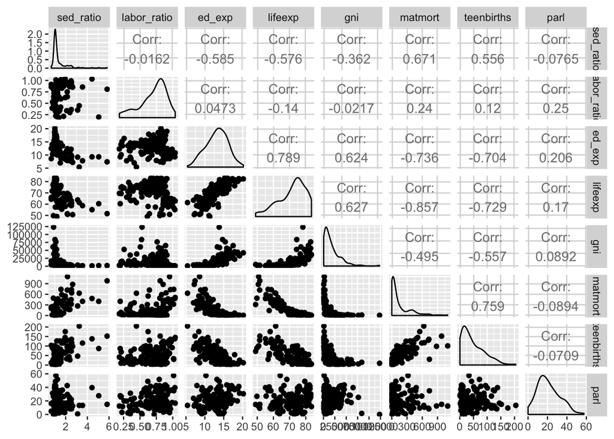

```r
pairs <- ggpairs(human)
pairs
```

```r
library(tidyverse)
```

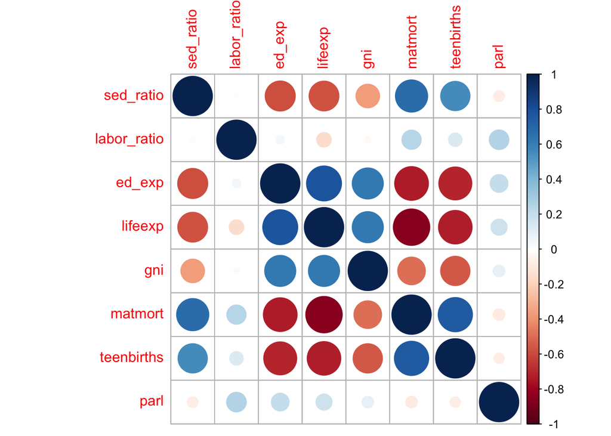

```r
library(corrplot)
# compute the correlation matrix and visualize it with corrplot
cor(human) %>% corrplot()
```

This dataframe contains 155 observations and 8 variables, 6 of them numerical and two interval. Based on their distributions, we can see that it’s a highly intercorrelated dataset, which is perfect for the purposes of the Principal Component Analysis.

Some of the variables in the data are strongly positively or negatively correlated: for instance, maternal mortality quite logically has a strong positive correlation with adolescent women giving birth. On the other hand, maternal mortality is strongly negatively correlated with expected education.

## PCA on non-standardized data

First, let’s try Principal Component Analysis on non-scaled data.

```r
pca_human <- prcomp(human)
pca_human
```

```
## Standard deviations (1, .., p=8):
## [1] 1.854416e+04 1.855223e+02 2.518704e+01 1.145442e+01 3.766254e+00
## [6] 1.569207e+00 5.345221e-01 1.720831e-01
##
## Rotation (n x k) = (8 x 8):
##                       PC1           PC2           PC3           PC4
## sed_ratio    1.438861e-05 -0.0022503438  0.0016047293 -1.006305e-03
## labor_ratio  2.331945e-07 -0.0002819336 -0.0005303524  4.692746e-03
## ed_exp      -9.562910e-05  0.0075529685 -0.0142769848  3.313605e-02
## lifeexp     -2.815823e-04  0.0283149570 -0.0129494322  6.752623e-02
## gni         -9.999832e-01 -0.0057723207  0.0005156755 -4.932869e-05
## matmort      5.655734e-03 -0.9916297159 -0.1260337001  6.102337e-03
## teenbirths   1.233961e-03 -0.1255500502  0.9918095255 -5.299293e-03
## parl        -5.526460e-05  0.0032317269  0.0073979127  9.971228e-01
##                       PC5           PC6           PC7           PC8
## sed_ratio    0.0034964012 -7.260101e-02 -9.945465e-01 -7.473545e-02
## labor_ratio  0.0022140041  3.308785e-02  7.249269e-02 -9.968063e-01
## ed_exp       0.1430816370  9.858861e-01 -7.363222e-02  2.784972e-02
## lifeexp      0.9865668049 -1.447742e-01  1.397970e-02 -1.280901e-03
## gni         -0.0001135872 -2.707883e-05  1.066685e-06 -1.814719e-07
## matmort      0.0266316436  1.829585e-03  1.946440e-03  6.376929e-04
## teenbirths   0.0188547462  1.284169e-02  1.016751e-03  2.495532e-05
## parl        -0.0716358797 -2.313031e-02  1.488159e-04  3.773314e-03
```

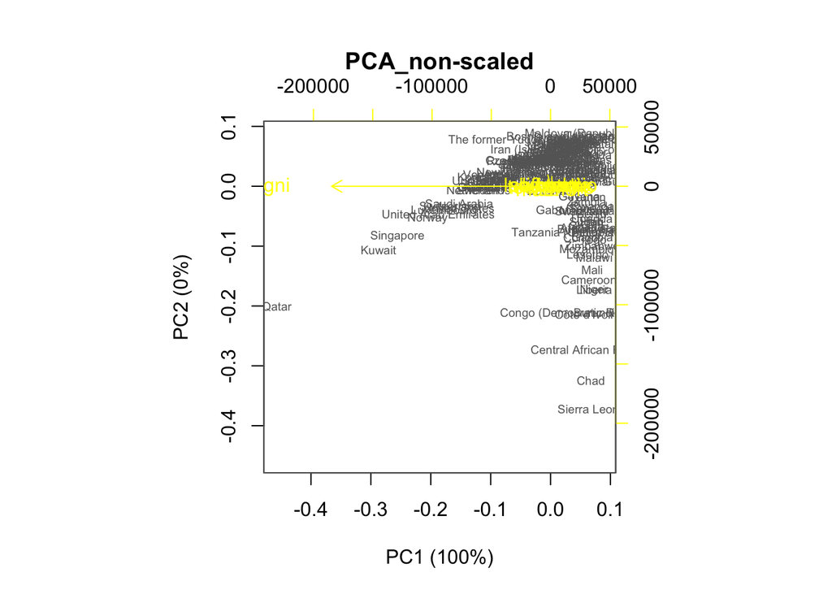

```r
# rounded percentages of variance captured by each PC
s <- summary(pca_human)
pca_pr <- round(100*s$importance[2,], digits = 1)

# create object pc_lab to be used as axis labels
pc_lab <- paste0(names(pca_pr), " (", pca_pr, "%)")

# draw a biplot of the principal component representation and the original variables
biplot(pca_human, choices = 1:2, cex = c(0.6, 1), col = c("grey40", "yellow"), xlab = pc_lab[1], ylab = pc_lab[2], main = (title = "PCA_non-scaled"))
```

We can immediately see from the summary of the model and the plot that the first component takes on 100% of the variance. This is due to the difference in ranges of the variables. For instance, the GNI per capita is represented by the longest axis, clearly has the biggest standard deviation. All the arrows are sitting on the same axis as if they are fully correlated.

Therefore, this analysis cannot be really taken into account.

## PCA on standardized data

```r
# standardize the variables
human_std <- scale(human)
summary(human_std)
```

```
##    sed_ratio         labor_ratio          ed_exp           lifeexp
##  Min.   :-0.92829   Min.   :-2.6247   Min.   :-2.7378   Min.   :-2.7188
##  1st Qu.:-0.47369   1st Qu.:-0.5484   1st Qu.:-0.6782   1st Qu.:-0.6425
##  Median :-0.38753   Median : 0.2316   Median : 0.1140   Median : 0.3056
##  Mean   : 0.00000   Mean   : 0.0000   Mean   : 0.0000   Mean   : 0.0000
##  3rd Qu.: 0.03306   3rd Qu.: 0.7350   3rd Qu.: 0.7126   3rd Qu.: 0.6717
##  Max.   : 6.06675   Max.   : 1.6632   Max.   : 2.4730   Max.   : 1.4218
##       gni             matmort          teenbirths           parl
##  Min.   :-0.9193   Min.   :-0.6992   Min.   :-1.1325   Min.   :-1.8203
##  1st Qu.:-0.7243   1st Qu.:-0.6496   1st Qu.:-0.8394   1st Qu.:-0.7409
##  Median :-0.3013   Median :-0.4726   Median :-0.3298   Median :-0.1403
##  Mean   : 0.0000   Mean   : 0.0000   Mean   : 0.0000   Mean   : 0.0000
##  3rd Qu.: 0.3712   3rd Qu.: 0.1932   3rd Qu.: 0.6030   3rd Qu.: 0.6127
##  Max.   : 5.6890   Max.   : 4.4899   Max.   : 3.8344   Max.   : 3.1850
```

```r
pca_human_std <- prcomp(human_std)
pca_human_std
```

```
## Standard deviations (1, .., p=8):
## [1] 2.0686801 1.1395786 0.8731156 0.8198145 0.6157250 0.5399602 0.4589378
## [8] 0.3258813
##
## Rotation (n x k) = (8 x 8):
##                     PC1         PC2         PC3         PC4        PC5
## sed_ratio    0.35428486 -0.03349747  0.26152597 -0.62161810  0.6060082
## labor_ratio  0.05429201  0.72405070 -0.60003871  0.01397768  0.2272492
## ed_exp      -0.42790065  0.14040242 -0.07383829 -0.09101094  0.1679844
## lifeexp     -0.44475461 -0.02380824  0.10661368 -0.05928025  0.1612152
## gni         -0.34485721  0.04901234 -0.12633930 -0.73711731 -0.5106521
## matmort      0.43894896  0.14353662 -0.10075255 -0.22918529 -0.1688594
## teenbirths   0.41461440  0.07478342  0.04257017  0.01639864 -0.4720253
## parl        -0.08438722  0.65249620  0.72581969  0.07390325 -0.1217201
##                     PC6          PC7         PC8
## sed_ratio   -0.15511613 -0.063047732 -0.15255603
## labor_ratio -0.04403599 -0.230781162 -0.07562945
## ed_exp      -0.37880046  0.780514915 -0.05040850
## lifeexp     -0.41364089 -0.430761634  0.63568952
## gni          0.14453049 -0.125313539 -0.14835638
## matmort      0.20112665  0.359359700  0.72521669
## teenbirths  -0.76068241 -0.055924672 -0.12588884
## parl         0.13940058  0.005956103 -0.02382852
```

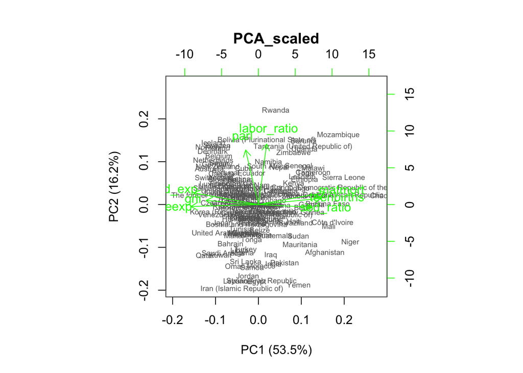

```r
# rounded percentages of variance captured by each PC
s_st <- summary(pca_human_std)
pca_pr_st <- round(100*s_st$importance[2,], digits = 1)

# create object pc_lab to be used as axis labels
pc_lab_st <- paste0(names(pca_pr_st), " (", pca_pr_st, "%)")

# draw a biplot of the principal component representation and the original variables
biplot(pca_human_std, choices = 1:2, cex = c(0.6, 1), col = c("grey40", "green"), xlab = pc_lab_st[1], ylab = pc_lab_st[2], main = (title = "PCA_scaled"))
```

The current analysis looks much more reliable. The countries are distibured throughout the bidimensional space. The first two principal components add up to 69.7% of the variance, typical for PCA.

Speculating about how to call the two dimensions, I would suggest “welfare” for PC1, because it collects indicators of health, social protection, and economic growth, and “participation” for PC2, since it is dealing with workforce and the participation rate. In the former, the variables mostly contributing to it are life expectancy at birth, GNI per capita, maternal maternity ratio, adolescent birth rate, expected years of education, and population with secondary education ratio. For the latter, the two main factors are representation in parliament and labor force prticipation ratio. Judging by the angles between the arrows along the two axis, the variables are closely correlated with each other. The length of the arrows became much more equal after the standardisation.

## Multiple correspondence analysis

```r
library(FactoMineR)
data(tea)

dim(tea)
```

```
## [1] 300  36
```

```r
str(tea)
```

```
## 'data.frame':    300 obs. of  36 variables:
##  $ breakfast       : Factor w/ 2 levels "breakfast","Not.breakfast": 1 1 2 2 1 2 1 2 1 1 ...
##  $ tea.time        : Factor w/ 2 levels "Not.tea time",..: 1 1 2 1 1 1 2 2 2 1 ...
##  $ evening         : Factor w/ 2 levels "evening","Not.evening": 2 2 1 2 1 2 2 1 2 1 ...
##  $ lunch           : Factor w/ 2 levels "lunch","Not.lunch": 2 2 2 2 2 2 2 2 2 2 ...
##  $ dinner          : Factor w/ 2 levels "dinner","Not.dinner": 2 2 1 1 2 1 2 2 2 2 ...
##  $ always          : Factor w/ 2 levels "always","Not.always": 2 2 2 2 1 2 2 2 2 2 ...
##  $ home            : Factor w/ 2 levels "home","Not.home": 1 1 1 1 1 1 1 1 1 1 ...
##  $ work            : Factor w/ 2 levels "Not.work","work": 1 1 2 1 1 1 1 1 1 1 ...
##  $ tearoom         : Factor w/ 2 levels "Not.tearoom",..: 1 1 1 1 1 1 1 1 1 2 ...
##  $ friends         : Factor w/ 2 levels "friends","Not.friends": 2 2 1 2 2 2 1 2 2 2 ...
##  $ resto           : Factor w/ 2 levels "Not.resto","resto": 1 1 2 1 1 1 1 1 1 1 ...
##  $ pub             : Factor w/ 2 levels "Not.pub","pub": 1 1 1 1 1 1 1 1 1 1 ...
##  $ Tea             : Factor w/ 3 levels "black","Earl Grey",..: 1 1 2 2 2 2 2 1 2 1 ...
##  $ How             : Factor w/ 4 levels "alone","lemon",..: 1 3 1 1 1 1 1 3 3 1 ...
```

[output cut: 22 more lines]

```r
summary(tea)
```

```
##          breakfast           tea.time          evening          lunch
##  breakfast    :144   Not.tea time:131   evening    :103   lunch    : 44
##  Not.breakfast:156   tea time    :169   Not.evening:197   Not.lunch:256
##
##
##
##
##
##         dinner           always          home           work
##  dinner    : 21   always    :103   home    :291   Not.work:213
##  Not.dinner:279   Not.always:197   Not.home:  9   work    : 87
##
##
##
##
##
##         tearoom           friends          resto          pub
##  Not.tearoom:242   friends    :196   Not.resto:221   Not.pub:237
##  tearoom    : 58   Not.friends:104   resto    : 79   pub    : 63
##
##
##
##
##
##         Tea         How           sugar                     how
##  black    : 74   alone:195   No.sugar:155   tea bag           :170
##  Earl Grey:193   lemon: 33   sugar   :145   tea bag+unpackaged: 94
##  green    : 33   milk : 63                  unpackaged        : 36
##                  other:  9
##
##
##
##                   where                 price          age        sex
##  chain store         :192   p_branded      : 95   Min.   :15.00   F:178
##  chain store+tea shop: 78   p_cheap        :  7   1st Qu.:23.00   M:122
##  tea shop            : 30   p_private label: 21   Median :32.00
##                             p_unknown      : 12   Mean   :37.05
##                             p_upscale      : 53   3rd Qu.:48.00
##                             p_variable     :112   Max.   :90.00
##
```

[output cut: 25 more lines]

```
##  feminine    :129   Not.sophisticated: 85   No.slimming:255
##  Not.feminine:171   sophisticated    :215   slimming   : 45
##
##
##
##
##
##         exciting          relaxing              effect.on.health
##  exciting   :116   No.relaxing:113   effect on health   : 66
##  No.exciting:184   relaxing   :187   No.effect on health:234
##
##
##
##
##
```

[figure not shown]

```r
library(ggplot2)
gather(tea) %>% ggplot(aes(value)) + facet_wrap("key", scales = "free") + geom_bar() + theme(axis.text.x = element_text(angle = 45, hjust = 1, size = 8))
```

The current dataframe is too big for a meaningful MCA analysis to my taste, so I chose nine to my best interest.

```r
# creating a subset
keep_columns <- c("Tea", "How", "how", "sugar", "home", "breakfast", "age", "sex", "frequency")
tea_time <- dplyr::select(tea, one_of(keep_columns))
summary(tea_time)
```

```
##         Tea         How                      how           sugar
##  black    : 74   alone:195   tea bag           :170   No.sugar:155
##  Earl Grey:193   lemon: 33   tea bag+unpackaged: 94   sugar   :145
##  green    : 33   milk : 63   unpackaged        : 36
##                  other:  9
##
##
##        home             breakfast        age        sex
##  home    :291   breakfast    :144   Min.   :15.00   F:178
##  Not.home:  9   Not.breakfast:156   1st Qu.:23.00   M:122
##                                     Median :32.00
##                                     Mean   :37.05
##                                     3rd Qu.:48.00
##                                     Max.   :90.00
##        frequency
##  1/day      : 95
##  1 to 2/week: 44
##  +2/day     :127
##  3 to 6/week: 34
##
##
```

```r
str(tea_time)
```

```
## 'data.frame':    300 obs. of  9 variables:
##  $ Tea      : Factor w/ 3 levels "black","Earl Grey",..: 1 1 2 2 2 2 2 1 2 1 ...
##  $ How      : Factor w/ 4 levels "alone","lemon",..: 1 3 1 1 1 1 1 3 3 1 ...
##  $ how      : Factor w/ 3 levels "tea bag","tea bag+unpackaged",..: 1 1 1 1 1 1 1 1 2 2 ...
##  $ sugar    : Factor w/ 2 levels "No.sugar","sugar": 2 1 1 2 1 1 1 1 1 1 ...
##  $ home     : Factor w/ 2 levels "home","Not.home": 1 1 1 1 1 1 1 1 1 1 ...
##  $ breakfast: Factor w/ 2 levels "breakfast","Not.breakfast": 1 1 2 2 1 2 1 2 1 1 ...
##  $ age      : int  39 45 47 23 48 21 37 36 40 37 ...
##  $ sex      : Factor w/ 2 levels "F","M": 2 1 1 2 2 2 2 1 2 2 ...
##  $ frequency: Factor w/ 4 levels "1/day","1 to 2/week",..: 1 1 3 1 3 1 4 2 3 3 ...
```

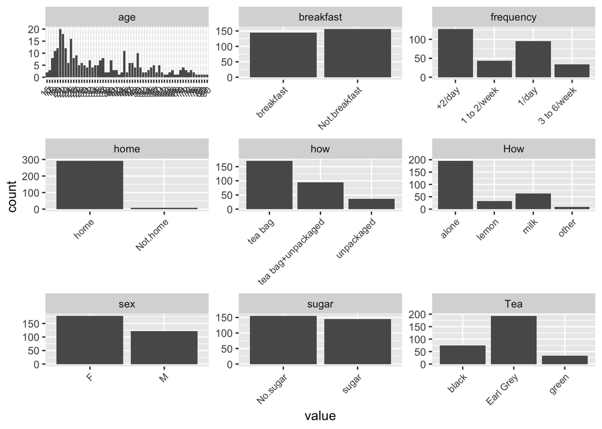

```r
library(ggplot2)
gather(tea_time) %>% ggplot(aes(value)) + facet_wrap("key", scales = "free") + geom_bar() + theme(axis.text.x = element_text(angle = 45, hjust = 1, size = 8))
```

A lot of young people and Earl Grey lovers who drink more than two cups a day (just like me).  
Prior to performing MCA, we need to transform the variables into factors, because MCA only operates on categorical variables.

```r
# prepare the data for MCA by converting all the variables to factors
colnames(tea_time)
```

```
## [1] "Tea"       "How"       "how"       "sugar"     "home"      "breakfast"
## [7] "age"       "sex"       "frequency"
```

```r
tea_time$Tea <- factor(tea_time$Tea)
tea_time$How <- factor(tea_time$How)
tea_time$how <- factor(tea_time$how)
tea_time$sugar <- factor(tea_time$sugar)
tea_time$home <- factor(tea_time$home)
tea_time$breakfast <- factor(tea_time$breakfast)
tea_time$age <- factor(tea_time$age)
tea_time$sex <- factor(tea_time$sex)
tea_time$frequency <- factor(tea_time$frequency)

# multiple correspondence analysis
mca <- MCA(tea_time, graph = FALSE)

# summary of the model
summary(mca)
```

```
##
## Call:
## MCA(X = tea_time, graph = FALSE)
##
##
## Eigenvalues
##                        Dim.1   Dim.2   Dim.3   Dim.4   Dim.5   Dim.6
## Variance               0.234   0.205   0.191   0.190   0.178   0.170
## % of var.              2.843   2.491   2.324   2.309   2.164   2.067
## Cumulative % of var.   2.843   5.334   7.658   9.968  12.132  14.199
##                        Dim.7   Dim.8   Dim.9  Dim.10  Dim.11  Dim.12
## Variance               0.162   0.157   0.153   0.150   0.147   0.139
## % of var.              1.973   1.914   1.866   1.825   1.793   1.687
## Cumulative % of var.  16.172  18.086  19.952  21.776  23.569  25.257
##                       Dim.13  Dim.14  Dim.15  Dim.16  Dim.17  Dim.18
## Variance               0.130   0.125   0.111   0.111   0.111   0.111
## % of var.              1.575   1.522   1.351   1.351   1.351   1.351
## Cumulative % of var.  26.832  28.354  29.705  31.056  32.408  33.759
##                       Dim.19  Dim.20  Dim.21  Dim.22  Dim.23  Dim.24
## Variance               0.111   0.111   0.111   0.111   0.111   0.111
## % of var.              1.351   1.351   1.351   1.351   1.351   1.351
## Cumulative % of var.  35.110  36.462  37.813  39.164  40.516  41.867
##                       Dim.25  Dim.26  Dim.27  Dim.28  Dim.29  Dim.30
## Variance               0.111   0.111   0.111   0.111   0.111   0.111
## % of var.              1.351   1.351   1.351   1.351   1.351   1.351
## Cumulative % of var.  43.218  44.570  45.921  47.272  48.624  49.975
##                       Dim.31  Dim.32  Dim.33  Dim.34  Dim.35  Dim.36
## Variance               0.111   0.111   0.111   0.111   0.111   0.111
## % of var.              1.351   1.351   1.351   1.351   1.351   1.351
## Cumulative % of var.  51.327  52.678  54.029  55.381  56.732  58.083
##                       Dim.37  Dim.38  Dim.39  Dim.40  Dim.41  Dim.42
## Variance               0.111   0.111   0.111   0.111   0.111   0.111
## % of var.              1.351   1.351   1.351   1.351   1.351   1.351
## Cumulative % of var.  59.435  60.786  62.137  63.489  64.840  66.191
##                       Dim.43  Dim.44  Dim.45  Dim.46  Dim.47  Dim.48
## Variance               0.111   0.111   0.111   0.111   0.111   0.111
## % of var.              1.351   1.351   1.351   1.351   1.351   1.351
## Cumulative % of var.  67.543  68.894  70.245  71.597  72.948  74.300
##                       Dim.49  Dim.50  Dim.51  Dim.52  Dim.53  Dim.54
## Variance               0.111   0.111   0.111   0.111   0.111   0.111
```

[output cut: 63 more lines]

```
## tea bag              0.064  -4.367 |   0.030   0.030   0.001   0.595 |
## tea bag+unpackaged   0.001  -0.484 |  -0.377   2.588   0.065  -4.403 |
## unpackaged           0.181   7.350 |   0.842   4.948   0.097   5.377 |
##
## Categorical variables (eta2)
##                      Dim.1 Dim.2 Dim.3
## Tea                | 0.188 0.191 0.344 |
## How                | 0.183 0.257 0.100 |
## how                | 0.058 0.187 0.130 |
## sugar              | 0.199 0.068 0.003 |
## home               | 0.172 0.010 0.007 |
## breakfast          | 0.271 0.174 0.007 |
## age                | 0.557 0.629 0.695 |
## sex                | 0.067 0.009 0.353 |
## frequency          | 0.409 0.317 0.081 |
```

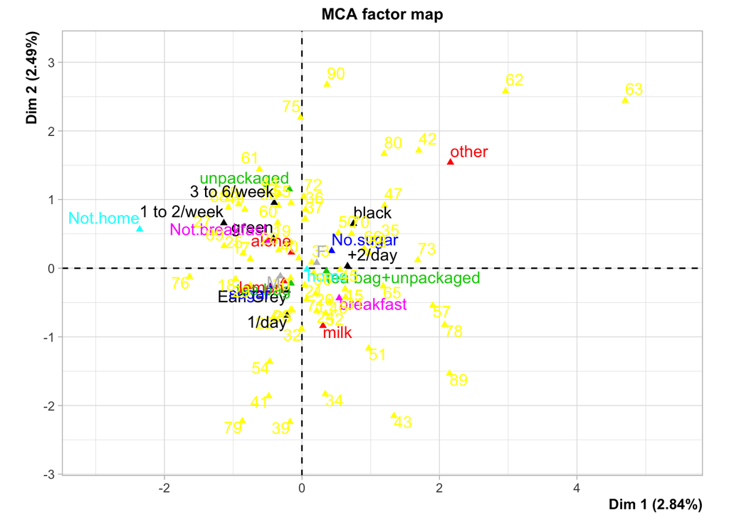

```r
# visualize MCA
plot(mca, invisible=c("ind"), habillage = "quali")
```

The MCA resulted in a quite a busy graph with not so great a level of variance coverage: just 2.84% for the first dimension and 2.49% for the second. Converting the whole age variable into a factor was not a brilliant idea either; I should have split it into more meaningful bins accroding to age groups.  
However, we can see some clusters: people who prefer Earl Grey love taking lemon and sugar with their drink once a day. Black-tea lovers drink it sugarless and twice a day or more. Finally, unfrequent tea-takers (from 1 to 6 times a week) lean towards drinking it not at breakfast, not at home, and without any of the fancy stuff.